# Essentials to Popular Apps: Analyzing the Success of Best Selling Apps on the Google Play Store

In this notebook, the goal is to find the best features to attract mobile application users. If we were to develop an app to publish on the Google Play Store, what kind of app would be most successful? For this purpose, we would like to find out some key things that make a popular app such as its category, price, size, etc.  
We will analyze existing data about the Google Play Store apps to find the best area to publish a new app. We will use the number of installs as an indicator of success and attempt to find relationships between the number of installs and different properties of an app. With a focus to maximize user install potential, we'll explore the following:

- What kind of apps are available in the market?
- What do users tend to download?
- Are there any factors influencing the consumers decisions?

### Summary of Results

After analyzing the data, a solid conclusion we reached is that the Books and Reference category would be an excellent place to deploy a new app, more specifically, multi-language dictionaries and mobile versions of popular literature. On the other hand, it is best to avoid the highly saturated market of Communication and Game category. We also found that there is a positive relationship between the size of an app and user satisfaction.  
More details are provided in the analysis below.

## About the Dataset

For this project, I will make use of an existing dataset of App metadata from the Google Play Store. This dataset is publicly available on [Kaggle](https://www.kaggle.com/lava18/google-play-store-apps) with over 10 thousand date entries.  
This section will be focused on cleaning the data and looking at the properties of data we will be using.  
There are 10841 apps recorded in this Google Play Store dataset. From preview of the dataset below, most of the columns seems to be potentially useful for the purpose for this anlaysis except for 'Last Updated' , 'Current Ver' and 'Android Ver'.

```python
# Load packages
import pandas as pd
import numpy as np
import seaborn as sns
import matplotlib.pyplot as plt
```

```python
# Read in the dataset
data = pd.read_csv("googleplaystore.csv")
data = data.loc[:, ~data.columns.str.contains('Unnamed')]
```

```python
data.head()
```

|  | App | Category | Rating | Reviews | Size | Installs | Type | Price | Content Rating | Genres | Last Updated | Current Ver | Android Ver |
| --- | --- | --- | --- | --- | --- | --- | --- | --- | --- | --- | --- | --- | --- |
| 0 | Photo Editor & Candy Camera & Grid & ScrapBook | ART_AND_DESIGN | 4.1 | 159 | 19M | 10,000+ | Free | 0 | Everyone | Art & Design | January 7, 2018 | 1.0.0 | 4.0.3 and up |
| 1 | Coloring book moana | ART_AND_DESIGN | 3.9 | 967 | 14M | 500,000+ | Free | 0 | Everyone | Art & Design;Pretend Play | January 15, 2018 | 2.0.0 | 4.0.3 and up |
| 2 | U Launcher Lite – FREE Live Cool Themes, Hide ... | ART_AND_DESIGN | 4.7 | 87510 | 8.7M | 5,000,000+ | Free | 0 | Everyone | Art & Design | August 1, 2018 | 1.2.4 | 4.0.3 and up |
| 3 | Sketch - Draw & Paint | ART_AND_DESIGN | 4.5 | 215644 | 25M | 50,000,000+ | Free | 0 | Teen | Art & Design | June 8, 2018 | Varies with device | 4.2 and up |
| 4 | Pixel Draw - Number Art Coloring Book | ART_AND_DESIGN | 4.3 | 967 | 2.8M | 100,000+ | Free | 0 | Everyone | Art & Design;Creativity | June 20, 2018 | 1.1 | 4.4 and up |

```python
data['Installs'].value_counts()
```

```
1,000,000+        1579
10,000,000+       1252
100,000+          1169
10,000+           1054
1,000+             907
5,000,000+         752
100+               719
500,000+           539
50,000+            479
5,000+             477
100,000,000+       409
10+                386
500+               330
50,000,000+        289
50+                205
5+                  82
500,000,000+        72
1+                  67
1,000,000,000+      58
0+                  14
Free                 1
0                    1
Name: Installs, dtype: int64
```

```python
bad_data = data[(data['Installs'] == 'Free')]
bad_data
```

|  | App | Category | Rating | Reviews | Size | Installs | Type | Price | Content Rating | Genres | Last Updated | Current Ver | Android Ver |
| --- | --- | --- | --- | --- | --- | --- | --- | --- | --- | --- | --- | --- | --- |
| 10472 | Life Made WI-Fi Touchscreen Photo Frame | 1.9 | 19.0 | 3.0M | 1,000+ | Free | 0 | Everyone | NaN | February 11, 2018 | 1.0.19 | 4.0 and up | NaN |

```python
# remove the invalid row
index = bad_data.index
data = data.drop(index)
```

As we mentioned in the introduction, we will be using the number of installs as a measure of popularity. There is one value in the column listed as Free, which is pretty strange. After taking a closer look at that specific row, it seems like all the values have shifted one column left to where they are supposed to be. Nevertheless, the values for this entire row are invalid so we will remove this row. Moreover, there are non-numeric characters in the column which we will also remove.

```python
data['Size'].value_counts()
```

```
Varies with device    1695
11M                    198
12M                    196
14M                    194
13M                    191
                      ...
186k                     1
175k                     1
485k                     1
809k                     1
28k                      1
Name: Size, Length: 461, dtype: int64
```

```python
# change size of KB to MB
data['Size'] = data['Size'].apply(lambda x: str(float(x.replace('k', '')) / 1000) if 'k' in x else x)

# replace non numeric size with NA
data['Size'] = data['Size'].replace('Varies with device', np.nan)

# remove distracting characters
symbols = ['M', ',', '+', '$']
affected_cols = ['Size', 'Installs', 'Price']
for col in affected_cols:
    # remove non numeric characters in these columns
    for char in symbols:
        data[col] = data[col].str.replace(char, '')
    # convert column to numeric data type
    data[col] = pd.to_numeric(data[col])
```

```python
# Drop duplicate entries
data = data.drop_duplicates(subset='App', keep='last')
```

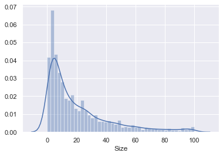

```python
sns.set(font_scale=1)
sns.distplot(data.Size)
```

```python
data['Size'] = data['Size'].fillna(data['Size'].median())
```

There are different units in the size column, and I will convert all the values of KB to MB. Furthermore, there are over a thousand undetermined values for the size of apps. Since we will use this column as part of the analysis, these missing values will be filled instead of removed. As the distribution of the App size is not normally distributed, I will fill the empty values with the median of the column values.

## What Is Available in the Market?

With almost three million applications available in the Google Play Store, it's a common practice for the market to section off apps based on their category so that users can find what they want more quickly.

In this section, we will answer these following questions:

- Are there any categories dominating the app store?
- What categories have the most user download?

Based on recent searches and the fact that the app store has a tab dedicated to games as its own section aside from the other apps, I expect that games will cover a large area of the market.

```python
total = len(data)
category_freq_df = data['Category'].value_counts().rename_axis('Category').reset_index(name='Counts')
category_freq_df['percentage'] = category_freq_df['Counts']/total*100
#category_freq_df
```

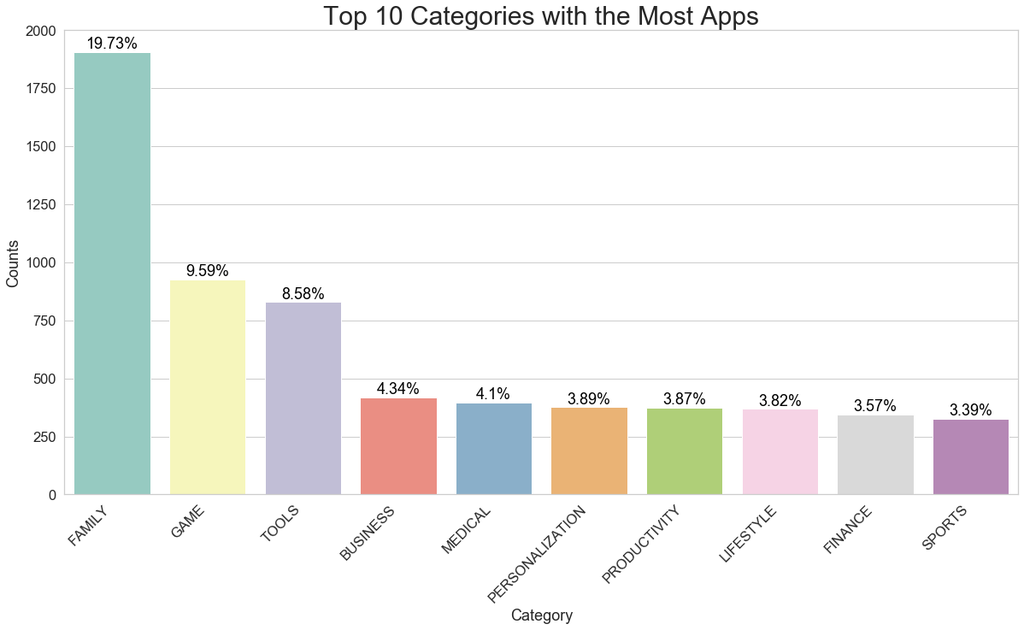

```python
# configuration of plot
labels = category_freq_df['percentage'].argsort().argsort()
palette = sns.color_palette("Set3", len(category_freq_df))
# plot configuration
sns.set(rc={'figure.figsize':(20,10)}, font_scale=1.5, style='whitegrid')

# category frequency plot
category_chart = sns.barplot(x="Category",
           y="Counts",
           palette=np.array(palette[::-1])[labels],
           data=category_freq_df.head(10))

# add percentage to the top of each bar
for index, row in category_freq_df.head(10).iterrows():
    category_chart.text(row.name,
                        row.Counts,
                        str(round(row.percentage, 2)) + '%',
                        color='black',
                        ha='center',
                        va='bottom'
                       )

category_chart.set_title('Top 10 Categories with the Most Apps', fontsize=30)
# configuration of labels
labels = category_chart.set_xticklabels(category_chart.get_xticklabels(),
                                        rotation=45,
                                        ha='right')
```

Over 35% of the apps are for practical use, such as Tools, Business, Productivity, etc. On the other hand, 29% of the apps are in the Family and Game category.  
Having a closer look at the Family category, we find that it is a collection of games and educational apps designed for children. As we are living in the information age, kids are exposed to digital entertainment at a young age (for example, video games and YouTube are very popular). Similarly, in recent years a lot of games companies have started to expand their products onto mobile platforms to attract new players, which resulted in a lot of new games in the apps market.  
About 65% of the market consists of games and productivity apps. But how are the user demands compared to its availability?

# What Are Users Into?

We've seen from above that apps in the genre of games and practical usage dominated the app market. Since there are so many of these apps, are they what the users want?  
In this section, we will look at how each category is doing by measuring the total installs, along with the average number of installs per category.

```python
# create dataframe with frequency of installs per category
category_df = (data
               .groupby('Category')['Installs']
               .sum().reset_index()
              )
# add the count of each category to dataframe as a column
# calculate the average installs per category
category_df = category_df.join(category_freq_df.set_index('Category'), on='Category')
category_df['average_install'] = category_df['Installs']/category_df['Counts']

category_df = category_df.sort_values(by='average_install', ascending=False)
```

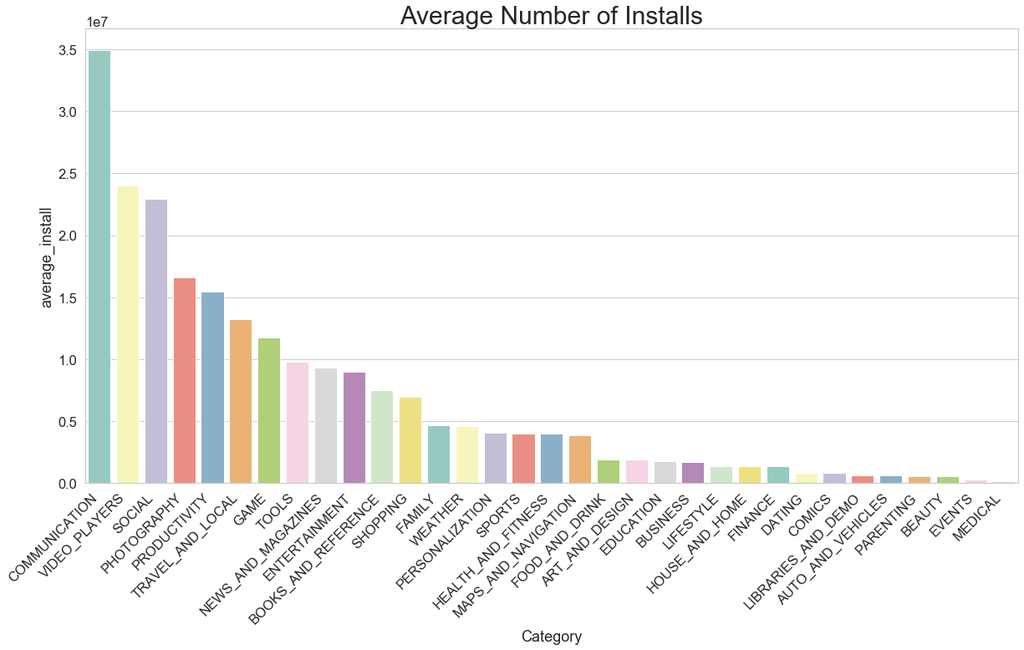

```python
# plot configuration
sns.set(rc={'figure.figsize':(20,10)}, font_scale=1.5, style='whitegrid')

# plot of average category installs
category_chart = sns.barplot(x="Category",
           y="average_install",
           palette="Set3",
           data=category_df)

# configuration of labels
category_chart.set_title('Average Number of Installs', fontsize=30)
labels = category_chart.set_xticklabels(category_chart.get_xticklabels(),
                                        rotation=45,
                                        ha='right')
```

```python
# filter dataframe with only communication apps and view first 10
comm_df = data[(data['Category'] == 'COMMUNICATION')].sort_values(by='Installs', ascending=False)
sub_comm = comm_df[['App', 'Installs']]
sub_comm.head(10)
```

|  | App | Installs |
| --- | --- | --- |
| 3904 | WhatsApp Messenger | 1000000000 |
| 3996 | Google Chrome: Fast & Secure | 1000000000 |
| 4096 | Gmail | 1000000000 |
| 4104 | Messenger – Text and Video Chat for Free | 1000000000 |
| 4153 | Hangouts | 1000000000 |
| 4234 | Skype - free IM & video calls | 1000000000 |
| 4222 | imo free video calls and chat | 500000000 |
| 3971 | UC Browser - Fast Download Private & Secure | 500000000 |
| 4039 | Google Duo - High Quality Video Calls | 500000000 |
| 4676 | Viber Messenger | 500000000 |

Communication apps have the most downloads, with over 34 Million downloads on average. Most of these downloads are from large companies such as WhatsApp, Google, Skype, and Messenger. These install counts could cause the number of Communication apps to be highly inflated compared to apps in other categories.

```python
# filter dataframe with only video player apps and view first 10
vp_df = data[(data['Category'] == 'VIDEO_PLAYERS')].sort_values(by='Installs', ascending=False)
sub_vp = vp_df[['App', 'Installs']]
sub_vp.head(10)
```

|  | App | Installs |
| --- | --- | --- |
| 3928 | YouTube | 1000000000 |
| 3687 | Google Play Movies & TV | 1000000000 |
| 4365 | MX Player | 500000000 |
| 3672 | Motorola Gallery | 100000000 |
| 4032 | Dubsmash | 100000000 |
| 4681 | VLC for Android | 100000000 |
| 4688 | VivaVideo - Video Editor & Photo Movie | 100000000 |
| 4696 | VideoShow-Video Editor, Video Maker, Beauty Ca... | 100000000 |
| 10647 | Motorola FM Radio | 100000000 |
| 3691 | Samsung Video Library | 50000000 |

Similarly, platforms like YouTube, Google Play Movies & TV, etc. have dominated the Video Player category with a large number of downloads.  
The trend continues in other categories with a high average download such as social(Facebook, Google+, Instagram), Photography(Google Photos), Productivity(Google Drive, Cloud Print), and so on.  
This situation signals two major flags for thinking about launching a new app in these categories.

1. The majority of installs come from a few apps, the category itself may not be as popular to the consumers
2. Large companies have already dominated these areas so it would be hard for a new app to stand out

To filter out a shorter list of categories suitable for deploying a new app, I will filter the list using the mean of app percentage(3.03) as an upper bound and the mean of average installs(6726102.56) as a lower bound.

```python
# list of categories to ignore
cat_list = ['VIDEO_PLAYERS','COMMUNICATION', 'SOCIAL','PHOTOGRAPHY','PRODUCTIVITY','TRAVEL_AND_LOCAL']

# create dataframe with boundaries discussed above
recom = category_df[~category_df.Category.isin(cat_list)]
recom = recom[(recom['percentage'] < 3.03) &
                    (recom['average_install']> 6726102.56)]
recom
```

|  | Category | Installs | Counts | percentage | average_install |
| --- | --- | --- | --- | --- | --- |
| 21 | NEWS_AND_MAGAZINES | 2369217760 | 254 | 2.629672 | 9.327629e+06 |
| 9 | ENTERTAINMENT | 708660000 | 79 | 0.817890 | 8.970380e+06 |
| 3 | BOOKS_AND_REFERENCE | 1665969576 | 222 | 2.298375 | 7.504367e+06 |
| 26 | SHOPPING | 1400348785 | 202 | 2.091314 | 6.932420e+06 |

Upon examining the list above, the immediate attention turns to the Entertainment category since it has a low market supply and a relatively high average install rate. After a closer look, the category is mostly filled with video streaming services(IMDb Movies & TV, Amazon Prime Video) or tools for connecting to another device(PlayStation App). This category could be useful for developers who are working with media streaming or similar industry.  
Alternatively, the Books and Reference category could also be a place for development. A quick look into the category we discover that there are some dictionaries available, but some of them only translate one language. Moreover, there are several apps for the Quran.  
Some potential app ideas we can make out of these observations:

- Dictionary providing a wide range of language translations
- App versions of popular/in-demand books

## Ratings and Reviews

We will now shift our attention to the rating and reviews of the apps. There are competitors in every field. And one of the ways user use to differentiate an app from another is by looking at the rating. When multiple apps are offering the same functionality, and we're not sure what is right for us, we're often inclined to make our decisions using information that we see, such as the rating. Generally, if there is an app with a visible better rating than it's competitors, then we are most likely going to choose that app over others.  
In this section, we will look at how the rating of an app is affected by different factors. Such as the app's category and the number of installs. We will answer the following questions:

- Is there any category that stands out from the crowd in term of app rating?
- Is there a relationship between an app's rating and the number of downloads?

```python
data.Rating.mean()
```

```
4.173218643240605
```

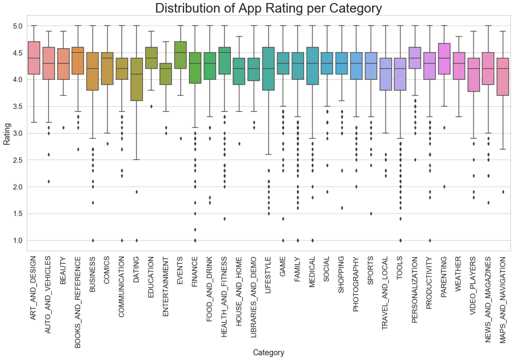

```python
# plot configurations
sns.set(rc={'figure.figsize':(20,10)}, font_scale=1.5, style='whitegrid')

boxplot=sns.boxplot(x='Category',
                    y='Rating',
                    data=data)

boxplot.set_title('Distribution of App Rating per Category',
                         fontsize=30)

labels = boxplot.set_xticklabels(boxplot.get_xticklabels(),
                                 rotation=90,
                                 ha='center')
```

We observe that most of the categories are performing well with the average rating being above 4, except for some exceptions such as Dating apps which has half of its apps rated below average. This finding indicates that the satisfactory level of the apps in this category is not high enough and that if a new dating app comes into the market that is better than the current ones, then it would attract more consumers interested in this field. This result could be a potential app idea that a developer interested in breaking into the Google Play Store market could explore.  
On the other hand, Books & Reference, Health & Fitness and Events have the best ratings with half of its apps rated above 4.5. This indicates that a large number of apps in these categories are of high quality. If we'd like to produce an app in these fields, we better make sure the app is well prepared to compete against the other high-quality apps.

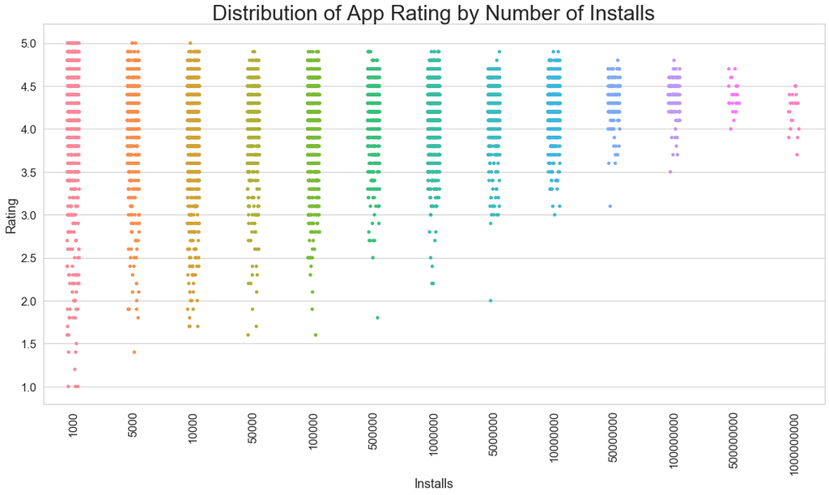

```python
# create subset with installs over 1000
review_df = data[data['Installs'] >=1000]
# plot configurations
sns.set(rc={'figure.figsize':(20,10)}, font_scale=1.5, style='whitegrid')

review_plot=sns.stripplot(x='Installs',
                    y='Rating',
                    data=review_df)

review_plot.set_title('Distribution of App Rating by Number of Installs',
                         fontsize=30)

labels = review_plot.set_xticklabels(review_plot.get_xticklabels(),
                                 rotation=90,
                                 ha='center')
```

Let's say an app has a 5-star review, that's great. But what if only has 1 or 2 reviews? There's a chance that it can be an excellent app, but statistically, the sample size in this scenario is too small to make the rating significant. To evaluate the graph with more confident, I filtered the dataset on apps with an install of 1000 and higher.  
We observe that apps with installs between 1000 to 500000 have a portion of its rating below 4. This phenomenon signals that an app with a low rating will hurt its downloads. On the other hand, a higher number of downloads all have a mean rating of at least 4. Although the difference is not drastic, we can see that apps as the rating increases, the number of downloads also increases. We are more inclined to download apps with a high rating because it signals that the app is well made.

## How Much Are You Willing to Pay?

Do people like to download free apps more than paid apps? In this section, we will explore the relationship between the price of an app, and it's the number of installs. We will also look at the price distribution of apps in each category.

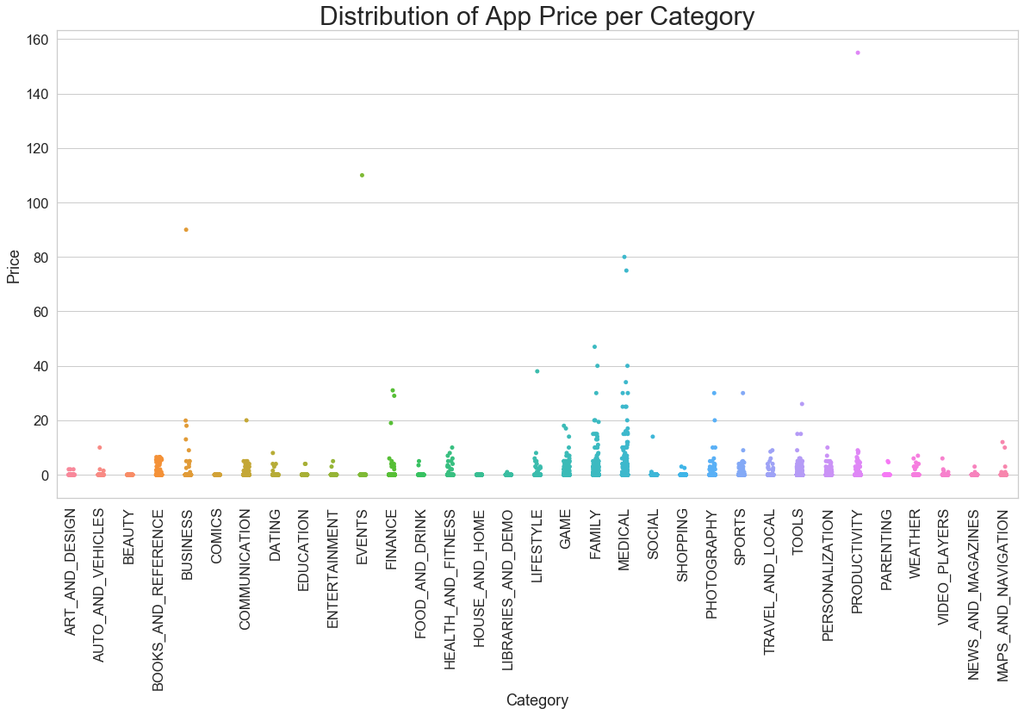

```python
# plot configurations
sns.set(rc={'figure.figsize':(20,10)}, font_scale=1.5, style='whitegrid')

price_plot=sns.stripplot(x='Category',
                    y='Price',
                    data=data[(data['Price']<200)])

price_plot.set_title('Distribution of App Price per Category',
                         fontsize=30)

labels = price_plot.set_xticklabels(price_plot.get_xticklabels(),
                                 rotation=90,
                                 ha='center')
```

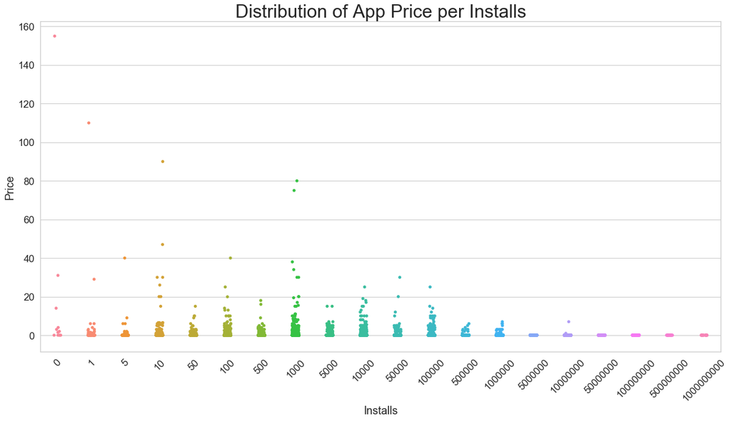

```python
# plot configurations
sns.set(rc={'figure.figsize':(20,10)}, font_scale=1.5, style='whitegrid')
rating_plot = sns.stripplot(x="Installs",
             y="Price",
             data=data[(data['Price']<200)])

rating_plot.set_title('Distribution of App Price per Installs',
                         fontsize=30)

labels = rating_plot.set_xticklabels(rating_plot.get_xticklabels(),
                                 rotation=45,
                                 ha='center')
```

Not surprisingly, most people prefer downloading free apps. Everyone(or most people) likes free stuff. If apps are offering what I need for free, why should I consider ones that I need to pay? Some developers publish multiple versions of the same app. There may be a listing for a free or lite version for people to try out the app, and if they want to upgrade(usually offering more advanced features) they often provide a 'pro' or 'premium' version for the cost of some money. Some people might convert to the paid version if they enjoyed the free version. Or if they're already satisfied with the free version, then they will keep using the free version, and this could be a reason why most downloads come from free apps since developers often offer a free version of an app with all essential features.  
On average, people are willing to buy an app for \$1 or less; a small group of people is willing to buy apps that cost more than \$20. There are a few apps with a listed price of over \$300. Upon examining what those apps are, it appears that there is a list of apps with a common title of 'I am rich'. The descriptions for these titles are more or less conveying the message that buying these apps makes the buyer look wealthy because the price is so ridiculously high. These are considered an outlier in this case, and thus I've removed them from the graph above.

## Size Doesn't Mean Everything. or Does It ?

Do people care about the size when deciding to download an app? Sometimes we don't have enough space on our phone and prefer a lightweight app. But does a bulky app steer people away from it? In this section, we will explore the relationship between the size of an app. By looking at different aspects such as the number of downloads, its category and rating, we will answer the following questions:

- Do people prefer large or small apps?
- How is the quality of the apps as compared to its size?
- Do games take up more space compared to other apps?

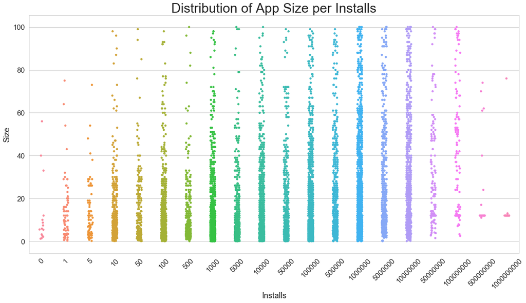

```python
# plot configurations
sns.set(rc={'figure.figsize':(20,10)}, font_scale=1.5, style='whitegrid')
size_plot = sns.stripplot(x="Installs",
                          y="Size",
                          data=data)

size_plot.set_title('Distribution of App Size per Installs',
                         fontsize=30)

labels = size_plot.set_xticklabels(size_plot.get_xticklabels(),
                                 rotation=45,
                                 ha='center')
```

There is a positive relationship between the size of an app and the number of installs for it. As the size of the app increases, the number of installs also increases. The more visually appealing an app is to the customer, the more likely they will download the app. Some of these visual aids could include attractive graphics, sounds, animations, etc. All these are effective in delivering an enjoyable experience to the user, with the cost of taking up more space, i.e. the app size will be much bigger than an app with minimal graphics. To investigate this further, we will look at how the size of an app can affect its rating.

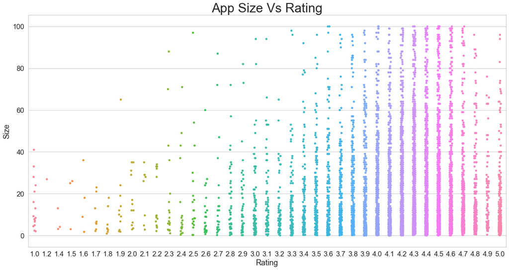

```python
# plot configurations
sns.set(rc={'figure.figsize':(20,10)}, font_scale=1.5, style='whitegrid')
size_rating_plot = sns.stripplot(x="Rating",
                          y="Size",
                          data=data)

size_rating_plot.set_title('App Size Vs Rating',
                         fontsize=30)

labels = size_rating_plot.set_xticklabels(size_rating_plot.get_xticklabels(), ha='center')
```

Similar to the above graph, there is a positive relationship between the size and rating of an app. On the other hand, notice that for highly-rated apps with a rating of 4.7 and above. The majority of the sizes are around 20MB, and this shows that although it is crucial to make an app attractive for the user, controlling the app to a reasonable size is also key to a high rating app. An app that is too large may take longer to load, and possibly slow down the user's device, which could result in a lower rating due to these problems. Next, we will look at the relationship between the size and the app's category.

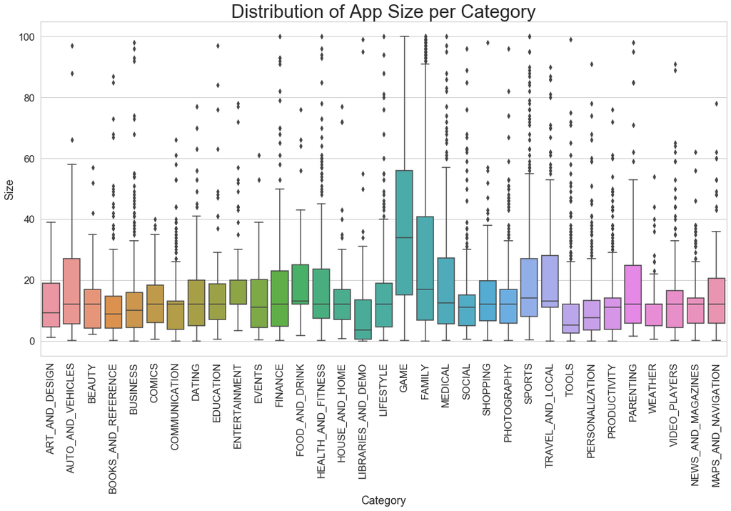

```python
# plot configurations
sns.set(rc={'figure.figsize':(20,10)}, font_scale=1.5, style='whitegrid')
size_category_plot = sns.boxplot(x="Category",
                          y="Size",
                          data=data)

size_category_plot.set_title('Distribution of App Size per Category',
                         fontsize=30)

labels = size_category_plot.set_xticklabels(size_category_plot.get_xticklabels(),
                                 rotation=90,
                                 ha='center')
```

Unsurprisingly, Games have the most significant size compare to other categories, with 50% of its apps ranging to nearly 60MB. We see that Family apps also have sizes similar to Games. Still, as we previously found out, the vast majority of Family apps are consist of games for kids, so it makes sense for the two categories to have a similar size. Most other categories are around 20MB, which is the average size for apps.

## Conclusion

In this notebook, we analyzed mobile app data from the Google Play Store to find the criteria in making a successful app. We first explored what is available in the market and what people tend to install. From this, we find that it is best to avoid the Communication and Game category because these fields are highly saturated. On the other hand, the Books and Reference category could be an excellent place to launch a new app due to high demands and low market supply.  
Next, we looked at the performance of apps of different categories through the app's rating and how it can affect the downloads. One thing that caught our attention was that Dating apps have a distinct lower rating compared to others. Furthermore, app rating has a positive relationship with the number of installs. These two information signals that there is potentially a market for Dating apps if it can outshine the current apps in the category.  
In terms of the price, it is best to keep the app free or under \$1. Unless we are publishing an app required for professional or medical fields, in that case, the pricing may vary depending on the content.  
As for the size of the app, it would be safe to keep the size under 20MB. However, if the app is heavily dependent on the graphic to enhance the user experience, such as a game, then it is okay to have the app slightly on the bulky side.  
In conclusion, a likely successful app would be one that is in high demand on the app market, free or cheap to lower barrier of entry, and lightweight to accommodate for low-end smartphone users.